# package editData : An RStudio Addin for Editing A ‘data.frame’

Keon-Woong Moon

2021-04-03

# editData

The ‘editData’ is an RStudio addin for editing a ‘data.frame’ or a ‘tibble’. Many RStudio users want to edit a data.frame. With this ‘editData’ package, you can delete, add or update a ‘data.frame’ without coding. You don’t have to use Microsoft excel or a csv editor any more to edit data. You can get resultant data as a ‘tibble’ or as a ‘data.frame’. You can read a csv file in the disk and save it as a csv format.

## Install package

You can install `editData` package from CRAN.

```r
install.packages("editData")
```

You can install the developmental version of `editData` package from github.

```r
#install.packages("devtools")
devtools::install_github("cardiomoon/editData")
```

After install this `editData` package you can see the `editData` addin in RStudio’s addins. (See the second plot).

## Usage: As an RStudio Add-in

This addin can be used to interactively manipulate a `data.frame` or a `tibble`. The intended way to use this is as follows:

1. Highlight a symbol naming a `data.frame` or a `tibble` in your R session, e.g. `mtcars`(1).

[figure not shown]

2. Execute this addin(arrow), to interactively manipulate it.

[figure not shown]

[figure not shown]

You can enter data name(4) to edit, upload a CSV or excel or RDS file(5) and download the edited data as a csv(6) or xlsx(7) or RDS (8)file.

4. If you press the edit button you can see this window. You can edit individual cell. You can delete the row or update the data.

[figure not shown]

5. Alternatively, you can edit a cell by double-click.

[figure not shown]

6 By default, the `sampleData` included in the `editData` package is selected. The `sex` and `bloodType` column are `factor` variables. A `selectInput` is assigned for a column of class factor.

[figure not shown]

7. A `dateInput` is assigned for a column of class `date`.

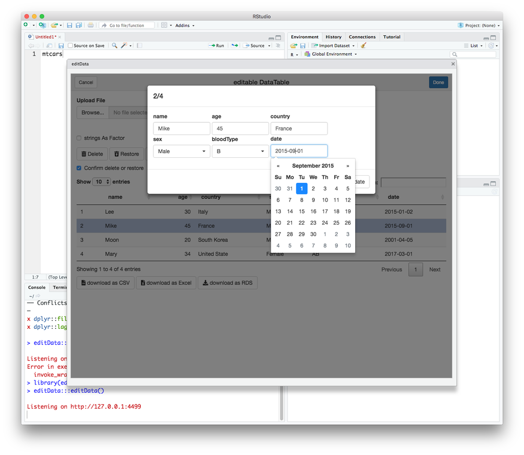

## Usage: As a regular function

You can use the `editData()` function as a regular function, e.g. in a command line.

```r
require(editData)
result <- editData(mtcars)
```

The resultant ‘tibble’ or ‘data.frame’ is assigned to the object `result`.

## Usage: As a shiny module

The `editData` package is made of modularized shiny functions. You can use the modularized `editableDTUI()` and `editableDT()` functions in your shiny app. In this package, I have included three examples in the `inst` folder. You can run these examples with one of the following codes.

```r
shiny::runApp(system.file('example',package='editData'))
shiny::runApp(system.file('multipleData',package='editData'))
shiny::runApp(system.file('multipleFiles',package='editData'))
```